# Solución — Clase 19

Análisis de Correspondencias Simple

**Código**

```r
library(tidyverse)
library(knitr)
source("../FuncionesCorrespondencias.R")
tabla <- margin.table(HairEyeColor, c(1, 2))
ajuste <- FactoMineR::CA(tabla, graph = FALSE)
resumen <- resumir_correspondencias(ajuste)
```

## 1. Resultados del ajuste

*Teoría relacionada: construcción algebraica del mapa e inercia total.*

**Código**

```r
kable(resumen$autovalores, digits = 3)
```

| dimension | autovalor | porcentaje | acumulado |
| --- | --- | --- | --- |
| 1 | 0.209 | 89.373 | 89.373 |
| 2 | 0.022 | 9.515 | 98.888 |
| 3 | 0.003 | 1.112 | 100.000 |

**Código**

```r
kable(resumen$filas, digits = 3)
```

| categoria | dimension | coordenada | contribucion | cos2 | tipo |
| --- | --- | --- | --- | --- | --- |
| Black | Dim 1 | 0.505 | 22.246 | 0.838 | Fila |
| Black | Dim 2 | -0.215 | 37.877 | 0.152 | Fila |
| Black | Dim 3 | -0.056 | 21.633 | 0.010 | Fila |
| Brown | Dim 1 | 0.148 | 5.086 | 0.864 | Fila |
| Brown | Dim 2 | 0.033 | 2.319 | 0.042 | Fila |
| Brown | Dim 3 | 0.049 | 44.284 | 0.094 | Fila |
| Red | Dim 1 | 0.130 | 0.964 | 0.133 | Fila |
| Red | Dim 2 | 0.320 | 55.131 | 0.812 | Fila |
| Red | Dim 3 | -0.083 | 31.913 | 0.055 | Fila |
| Blond | Dim 1 | -0.835 | 71.704 | 0.993 | Fila |
| Blond | Dim 2 | -0.070 | 4.673 | 0.007 | Fila |
| Blond | Dim 3 | -0.016 | 2.171 | 0.000 | Fila |

**Código**

```r
kable(resumen$columnas, digits = 3)
```

| categoria | dimension | coordenada | contribucion | cos2 | tipo |
| --- | --- | --- | --- | --- | --- |
| Brown | Dim 1 | 0.492 | 43.116 | 0.967 | Columna |
| Brown | Dim 2 | -0.088 | 13.042 | 0.031 | Columna |
| Brown | Dim 3 | -0.022 | 6.680 | 0.002 | Columna |
| Blue | Dim 1 | -0.547 | 52.128 | 0.977 | Columna |
| Blue | Dim 2 | -0.083 | 11.244 | 0.022 | Columna |
| Blue | Dim 3 | 0.005 | 0.310 | 0.000 | Columna |
| Hazel | Dim 1 | 0.213 | 3.401 | 0.542 | Columna |
| Hazel | Dim 2 | 0.167 | 19.804 | 0.336 | Columna |
| Hazel | Dim 3 | 0.101 | 61.086 | 0.121 | Columna |
| Green | Dim 1 | -0.162 | 1.355 | 0.176 | Columna |
| Green | Dim 2 | 0.339 | 55.910 | 0.773 | Columna |
| Green | Dim 3 | -0.088 | 31.925 | 0.052 | Columna |

**Código**

```r
c(
  dimensiones_maximas = min(nrow(tabla) - 1, ncol(tabla) - 1),
  suma_autovalores = sum(resumen$autovalores$autovalor),
  inercia_chi2 = resumir_tabla_contingencia(tabla)$prueba_chi2$inercia
)
```

```
dimensiones_maximas    suma_autovalores        inercia_chi2
          3.0000000           0.2335977           0.2335977
```

## 2. Elegir el plano

*Teoría relacionada: coordenadas principales y el mapa como aproximación.*

**Código**

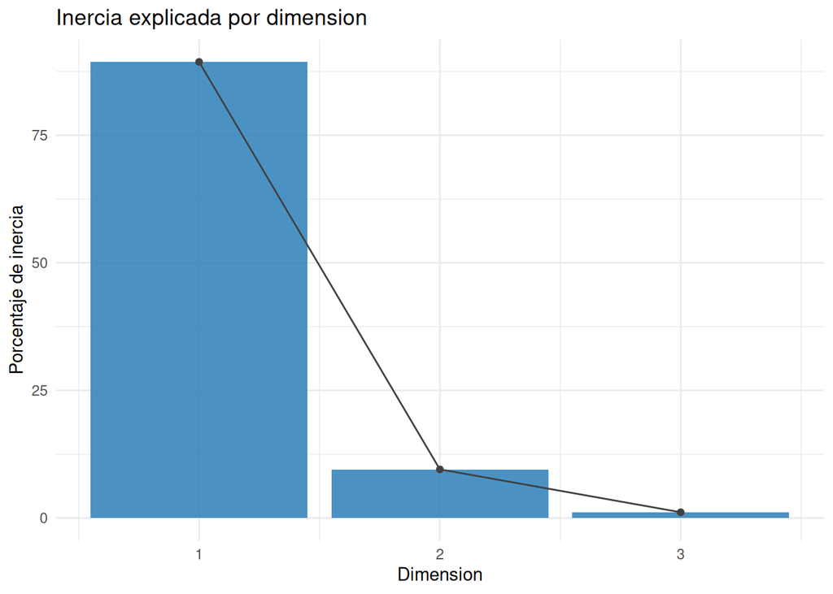

```r
visualizar_inercia_correspondencias(ajuste)
```

**Código**

```r
kable(resumen$autovalores |> select(dimension, porcentaje, acumulado), digits = 2)
```

| dimension | porcentaje | acumulado |
| --- | --- | --- |
| 1 | 89.37 | 89.37 |
| 2 | 9.51 | 98.89 |
| 3 | 1.11 | 100.00 |

Dos dimensiones retienen casi toda la inercia y son apropiadas para comunicar el patrón; una dimensión simplifica mucho, pero oculta el segundo contraste.

## 3. Construir los ejes

*Teoría relacionada: contribuciones.*

**Código**

```r
resultados_contrib <- list()
for (d in 1:2) {
  resultados_contrib[[paste0("filas_", d)]] <- contribuciones_correspondencias(ajuste, "filas", d)
  resultados_contrib[[paste0("columnas_", d)]] <- contribuciones_correspondencias(ajuste, "columnas", d)
}
kable(resultados_contrib$filas_1$tabla, digits = 2)
```

| categoria | contribucion |
| --- | --- |
| Blond | 71.70 |
| Black | 22.25 |
| Brown | 5.09 |
| Red | 0.96 |

**Código**

```r
kable(resultados_contrib$columnas_1$tabla, digits = 2)
```

| categoria | contribucion |
| --- | --- |
| Blue | 52.13 |
| Brown | 43.12 |
| Hazel | 3.40 |
| Green | 1.35 |

**Código**

```r
kable(resultados_contrib$filas_2$tabla, digits = 2)
```

| categoria | contribucion |
| --- | --- |
| Red | 55.13 |
| Black | 37.88 |
| Blond | 4.67 |
| Brown | 2.32 |

**Código**

```r
kable(resultados_contrib$columnas_2$tabla, digits = 2)
```

| categoria | contribucion |
| --- | --- |
| Green | 55.91 |
| Hazel | 19.80 |
| Brown | 13.04 |
| Blue | 11.24 |

**Código**

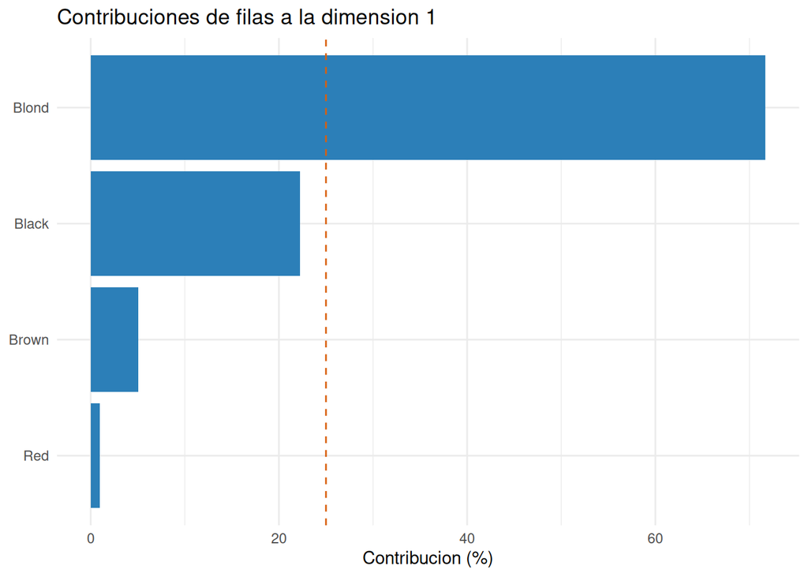

```r
resultados_contrib$filas_1$grafico
```

**Código**

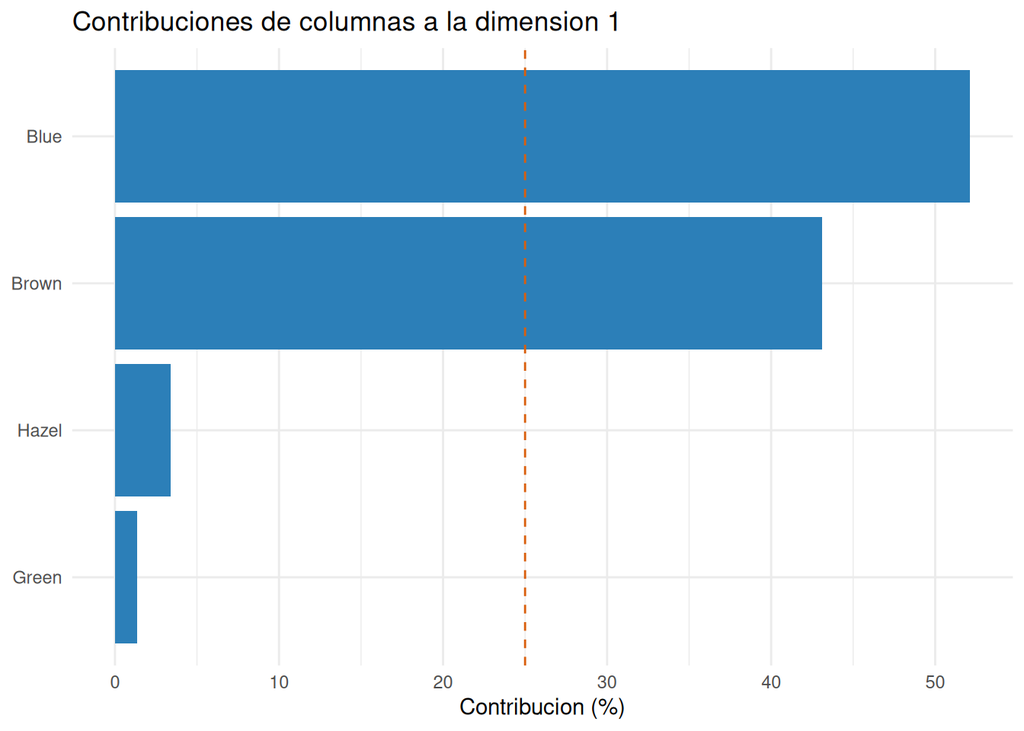

```r
resultados_contrib$columnas_1$grafico
```

La dimensión 1 contrapone principalmente pelo rubio y negro y ojos azules y marrones. La orientación de signos es arbitraria: multiplicar todas las coordenadas de un eje por $-1$ refleja el mapa sin cambiar distancias ni asociaciones.

## 4. Contribución y calidad

*Teoría relacionada: contribuciones y cos² o calidad de representación.*

**Código**

```r
calidad_f <- calidad_correspondencias(ajuste, "filas", 1:2)
calidad_c <- calidad_correspondencias(ajuste, "columnas", 1:2)
kable(calidad_f$tabla, digits = 3)
```

| categoria | cos2_plano |
| --- | --- |
| Brown | 0.906 |
| Red | 0.945 |
| Black | 0.990 |
| Blond | 1.000 |

**Código**

```r
kable(calidad_c$tabla, digits = 3)
```

| categoria | cos2_plano |
| --- | --- |
| Hazel | 0.879 |
| Green | 0.948 |
| Brown | 0.998 |
| Blue | 1.000 |

**Código**

```r
comparacion_filas <- resumen$filas |>
  filter(dimension == "Dim 1") |>
  select(categoria, contribucion_dim1 = contribucion) |>
  left_join(calidad_f$tabla, by = "categoria")
kable(comparacion_filas, digits = 3)
```

| categoria | contribucion_dim1 | cos2_plano |
| --- | --- | --- |
| Black | 22.246 | 0.990 |
| Brown | 5.086 | 0.906 |
| Red | 0.964 | 0.945 |
| Blond | 71.704 | 1.000 |

La contribución responde a quién construye el eje; el cos², a si el plano representa bien al punto.

## 5. Mapa y distancias

*Teoría relacionada: aproximación de las distancias e interpretación de proximidades.*

**Código**

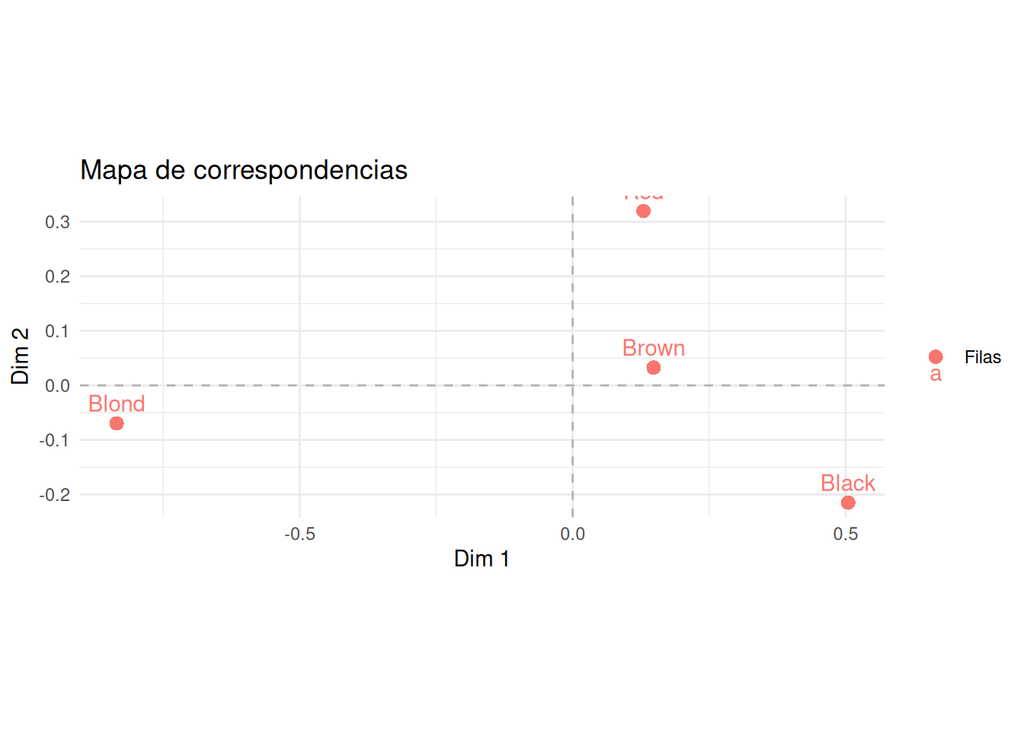

```r
visualizar_correspondencias(ajuste, "filas")
```

**Código**

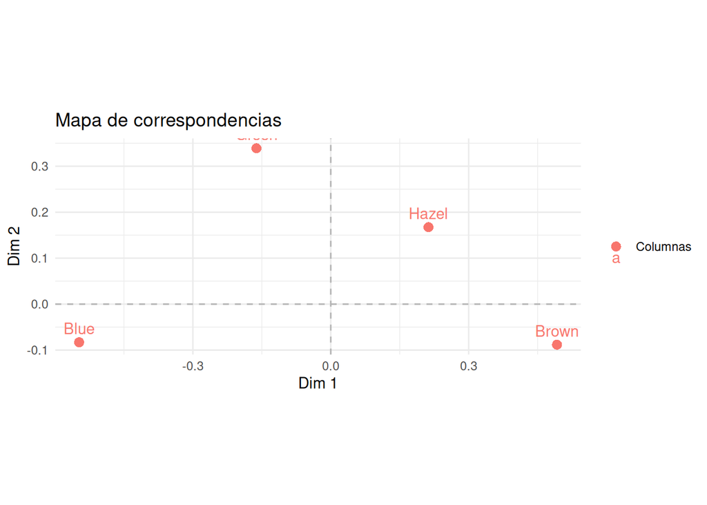

```r
visualizar_correspondencias(ajuste, "columnas")
```

**Código**

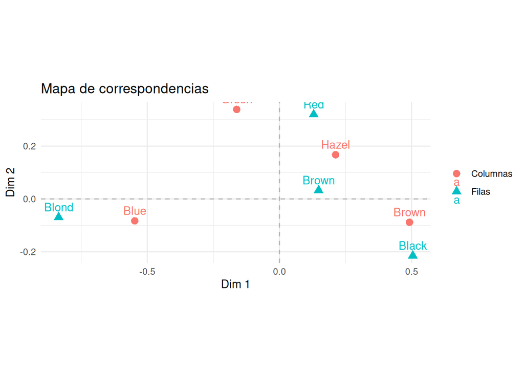

```r
visualizar_correspondencias(ajuste, "ambos")
```

**Código**

```r
D_chi <- as.matrix(distancias_chi2(tabla, "filas"))
D_completo <- as.matrix(dist(ajuste$row$coord))
D_una <- as.matrix(dist(ajuste$row$coord[, 1, drop = FALSE]))
c(
  error_todas_dimensiones = max(abs(D_chi - D_completo)),
  error_una_dimension = max(abs(D_chi - D_una))
)
```

```
error_todas_dimensiones     error_una_dimension
           8.881784e-16            2.976852e-01
```

**Código**

```r
ij <- which(lower.tri(D_chi), arr.ind = TRUE)
errores <- tibble(
  fila_1 = rownames(D_chi)[ij[, 1]],
  fila_2 = colnames(D_chi)[ij[, 2]],
  distancia_chi2 = D_chi[ij],
  distancia_1D = D_una[ij],
  perdida = D_chi[ij] - D_una[ij]
) |> arrange(desc(perdida))
kable(head(errores, 4), digits = 3)
```

| fila_1 | fila_2 | distancia_chi2 | distancia_1D | perdida |
| --- | --- | --- | --- | --- |
| Red | Brown | 0.316 | 0.019 | 0.298 |
| Red | Black | 0.654 | 0.375 | 0.278 |
| Brown | Black | 0.446 | 0.356 | 0.090 |
| Blond | Red | 1.043 | 0.965 | 0.078 |

Las asociaciones fila–columna, como rubio–azul o negro–marrón, deben confirmarse con perfiles o residuos. La distancia directa fila–columna del mapa conjunto no tiene la interpretación métrica de las distancias entre puntos del mismo tipo.

## 6. Informe

*Teoría relacionada: protocolo de decisión y errores frecuentes.*

La tabla admite tres dimensiones, pero las dos primeras retienen casi toda la inercia. Los ejes se nombran usando categorías con contribución alta y se interpretan solo cuando su cos² es suficiente. El plano reproduce bien la geometría principal, aunque una sola dimensión distorsiona algunas parejas. Las proximidades fila–columna son pistas de asociación, no distancias probabilísticas ni evidencia causal.